# Introduction to R functionality – Part 2

## Columns of a data frame are vectors

We saw how we can extract and visualise specific elements from a data frame, but how can we actually get data out of a data frame?

If you think about it, a data frame is just a list of column vectors. we can use the dollar sign `$` to retrieve a column (or columns) by using the `head()` function

```r
head(data$classes)
```

```
[1] 2 2 2 2 1 1
```

By default head shows the first 6 rows of a vector/column but if we want to visualise more we can specify it:

```r
head(data$classes,10)
```

```
 [1] 2 2 2 2 1 1 1 1 2 2
```

If we want to look at the fiew last rows, we can use the `tail()` function:

```r
tail(data$classes)
```

```
[1] 2 2 1 1 1 1
```

```r
# or
tail(data$classes,10) # for the last 10
```

```
 [1] 1 1 2 2 2 2 1 1 1 1
```

Using the dollar sign `$` we can also extarct specific elements without the `head()` or `tail()` functions:

```r
# ectract 5th value  of the column classes
data$classes[5]
```

```
[1] 1
```

Given that in a data frame each column/vector is also a variable, think of `$` as a means to extract a variable.

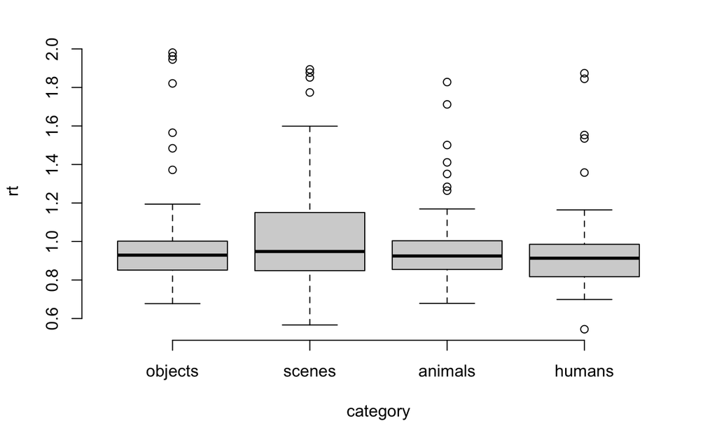

```r
# create box plots
boxplot(rt ~ category, data = data, frame = FALSE,
        names = c("objects", "scenes", "animals", "humans"))
```

Creating boxplots this way comes with R base, meaning that we do not need any packages, however we will also learn to use the package `ggplot2` for more powerfull plots with R. Notice that we did not need to use the dollar sign `$` to specify the variables we need? This is because we have the option to specify the data frame using the `data` argument. We could also write it this way:

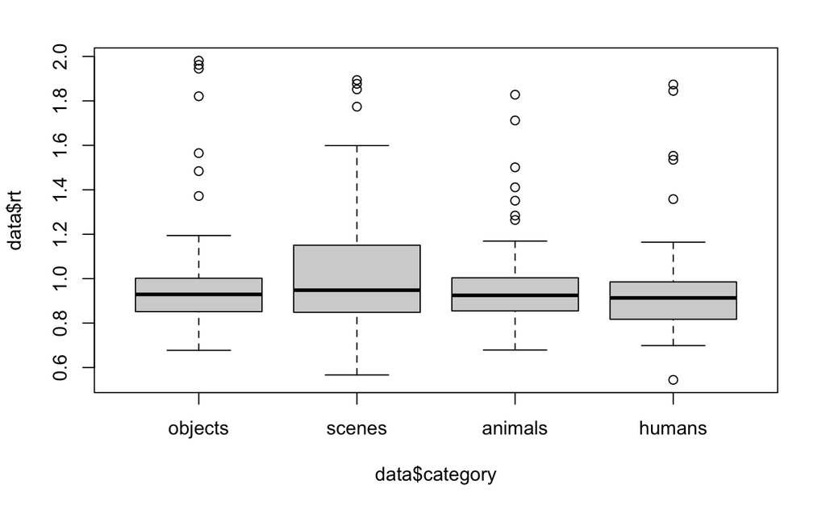

```r
boxplot(data$rt ~ data$category, frame = TRUE,
        names = c("objects", "scenes", "animals", "humans"))
```

## Factors in data frames

In R factor is variable used to categorise and store the data, having a limited number of different values. A Factor stores the data as a vector of integer values or strings. A factor is also known as a categorical variable with levels used mostly in statistical modelling and exploratory data analysis with R.

In this dataset we only have 1 continuous variable (rt) which stores the reaction times of each participant for living and non-living stimuli. So, the variable classes is a categorical variable (or factor), and it has two levels: **1: living** and **2: non-living**. We can also create a new variable/vector in the dataframe which will convert the two levels of the factor **classes** in string characters:

```r
# create new column in the data dataframe:
data$class = factor(data$classes,
                    levels = c("1", "2"),
                    labels = c("living", "non-living"))
```

### Exersice

Given that we have 3 categorical variables in our dataframe (classes, gender, category or cat), as an exercise, create a new variable for gender and category (or cat), in which the levels will be strings instead of numbers.

### More on factors:

We can also use the `count` function from `dplyr` to understand the columns/vectors of the dataframe:

```r
# count the observations/units for each of the two levels of the class factor
count(data, class)
```

| class | n |
| --- | --- |
| living | 96 |
| non-living | 96 |

This is an easy to handle dataset, because the number of observations/units for each condition/level of the factors is the same.

When we use `plot` with factorial data, it outputs a bar plot:

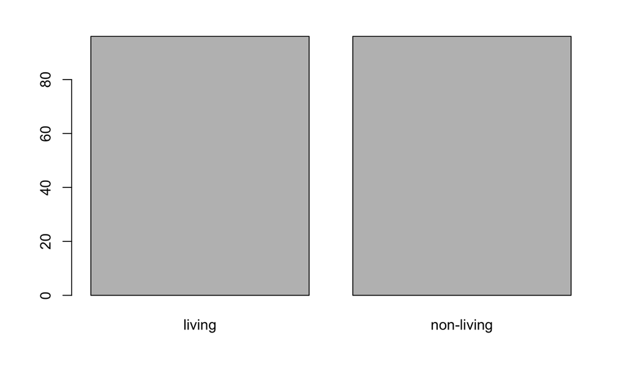

```r
plot(data$class)
```

Note that the vectors class and classes are not handled in the same way in R. This is because R handles the **class** vector as factor (with levels and labels) but **classes** is just a variable with categorical data. Let’s plot the vector **classes** to actually see the difference:

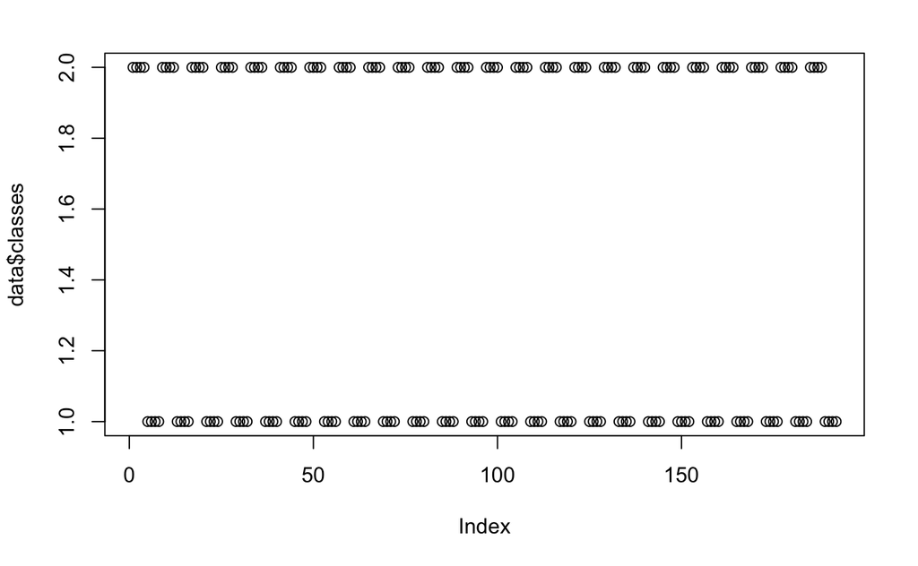

```r
plot(data$classes)
```

As sees, the levels of the factorial vector **class** has levels in order and associated labels (living vs non-living) which R can read, while the vector **classes** doesn’t.

To better understand this, try the `count` function with the **classes** vector instead of the **class** vector.

```r
count(data, classes)
```

| classes | n |
| --- | --- |
| 1 | 96 |
| 2 | 96 |

Notice the difference? R read the **class** vector as factor , while the **classes** vector as integer . This is why, converting the categorical data to factorial is highly recommended in R. It is much easier to manipulate and handle factors.

## Logical indexing

Logical indexing is another way of specifying the row numbers that we want to extract. We give a logical vector which is `TRUE` for the rows we want `FALSE` otherwise. We can use logical indexing as vector first using R base and the using the `dplyr` package.

Let’s look at rts that are shorter that 0.6 sec:

```r
short.rts = data$rt < 0.6

short.rts
```

```
  [1] FALSE FALSE FALSE FALSE FALSE FALSE FALSE FALSE FALSE FALSE FALSE FALSE FALSE FALSE
 [15] FALSE FALSE FALSE FALSE FALSE FALSE FALSE FALSE FALSE FALSE FALSE FALSE FALSE FALSE
 [29] FALSE FALSE FALSE FALSE FALSE FALSE FALSE FALSE FALSE FALSE FALSE FALSE FALSE FALSE
 [43] FALSE FALSE FALSE FALSE FALSE FALSE FALSE FALSE FALSE FALSE FALSE FALSE FALSE FALSE
 [57] FALSE FALSE FALSE FALSE FALSE FALSE FALSE FALSE FALSE FALSE FALSE FALSE FALSE FALSE
 [71] FALSE FALSE FALSE FALSE FALSE FALSE FALSE FALSE FALSE FALSE FALSE FALSE FALSE FALSE
 [85] FALSE FALSE FALSE FALSE FALSE FALSE FALSE FALSE FALSE FALSE FALSE FALSE FALSE FALSE
 [99] FALSE FALSE FALSE FALSE FALSE FALSE FALSE FALSE FALSE FALSE FALSE FALSE FALSE FALSE
[113] FALSE FALSE  TRUE FALSE FALSE FALSE  TRUE FALSE FALSE FALSE FALSE FALSE FALSE FALSE
[127] FALSE FALSE FALSE FALSE FALSE FALSE FALSE FALSE FALSE FALSE FALSE FALSE FALSE FALSE
[141] FALSE FALSE FALSE FALSE FALSE FALSE FALSE FALSE FALSE FALSE FALSE FALSE FALSE FALSE
[155] FALSE FALSE FALSE FALSE FALSE FALSE FALSE FALSE FALSE FALSE FALSE FALSE FALSE FALSE
[169] FALSE FALSE FALSE FALSE FALSE FALSE FALSE FALSE FALSE FALSE FALSE FALSE FALSE FALSE
[183] FALSE FALSE FALSE FALSE FALSE FALSE FALSE FALSE FALSE FALSE
```

We can also summarise the elements of the indexed vector using the `sum()` function. `Sum()` treats TRUE as 1 and FALSE as 0, so it will return the number of TRUE elements in the vector:

```r
sum(short.rts)
```

```
[1] 2
```

We can use the vector of logical values to extract all the information of those TRUE elements from the data frame:

```r
data[short.rts,]
```

|  | subj | rt | classes | cat | gender | category | class |
| --- | --- | --- | --- | --- | --- | --- | --- |
| 115 | 15 | 0.5667 | 2 | 3 | 2 | 2 | non-living |
| 119 | 15 | 0.5445 | 1 | 7 | 2 | 4 | living |

These are the comparison operators available:

- equal to: `a == b`
- not equal to: `a != b`
- less than: `a < b`
- greater than: `a > b`
- less than or equal to: `a <= b` *greater than or equal to: `a >= b`

We can also extract more complicated conditions using logical operators:

- TRUE, only when both a and b are TRUE: `a & b`
- TRUE, if either a or b or both are TRUE: `a | b`
- TRUE if a is false and FALSE if a is true: `! a`

```r
eight.onlyliving = data$rt > 0.8
nine.onlyliving = data$rt < 0.9

eight = eight.onlyliving & nine.onlyliving
sum(eight)
```

```
[1] 54
```

```r
eight
```

```
  [1] FALSE FALSE FALSE FALSE FALSE FALSE FALSE FALSE FALSE FALSE FALSE FALSE FALSE FALSE
 [15] FALSE  TRUE  TRUE  TRUE  TRUE  TRUE  TRUE  TRUE  TRUE FALSE FALSE FALSE FALSE FALSE
 [29] FALSE FALSE FALSE  TRUE FALSE FALSE FALSE FALSE FALSE FALSE FALSE FALSE FALSE FALSE
 [43] FALSE FALSE FALSE FALSE FALSE FALSE FALSE FALSE FALSE FALSE FALSE FALSE FALSE FALSE
 [57] FALSE FALSE FALSE FALSE FALSE FALSE FALSE FALSE  TRUE  TRUE  TRUE  TRUE  TRUE  TRUE
 [71]  TRUE  TRUE FALSE FALSE FALSE FALSE FALSE FALSE FALSE FALSE FALSE FALSE FALSE FALSE
 [85] FALSE FALSE FALSE FALSE FALSE FALSE FALSE FALSE FALSE FALSE FALSE FALSE FALSE FALSE
 [99] FALSE FALSE FALSE FALSE FALSE FALSE  TRUE  TRUE  TRUE  TRUE  TRUE  TRUE FALSE FALSE
[113] FALSE FALSE FALSE FALSE FALSE FALSE FALSE FALSE  TRUE  TRUE  TRUE  TRUE  TRUE  TRUE
[127] FALSE FALSE  TRUE  TRUE  TRUE  TRUE FALSE  TRUE  TRUE  TRUE FALSE  TRUE  TRUE  TRUE
[141]  TRUE  TRUE  TRUE FALSE FALSE FALSE FALSE FALSE FALSE FALSE FALSE FALSE FALSE FALSE
[155] FALSE FALSE  TRUE FALSE FALSE FALSE FALSE FALSE FALSE FALSE FALSE FALSE FALSE FALSE
[169] FALSE FALSE FALSE FALSE FALSE FALSE FALSE FALSE  TRUE  TRUE  TRUE FALSE  TRUE  TRUE
[183] FALSE  TRUE  TRUE  TRUE FALSE FALSE  TRUE FALSE  TRUE  TRUE
```

Now let’s find those extracted elements in the dataframe:

```r
data[eight,]
```

|  | subj | rt | classes | cat | gender | category | class |
| --- | --- | --- | --- | --- | --- | --- | --- |
| 16 | 2 | 0.85654 | 1 | 8 | 1 | 4 | living |
| 17 | 3 | 0.81618 | 2 | 1 | 1 | 1 | non-living |
| 18 | 3 | 0.82034 | 2 | 2 | 1 | 1 | non-living |
| 19 | 3 | 0.85454 | 2 | 3 | 1 | 2 | non-living |
| 20 | 3 | 0.81282 | 2 | 4 | 1 | 2 | non-living |
| 21 | 3 | 0.82958 | 1 | 5 | 1 | 3 | living |
| 22 | 3 | 0.80657 | 1 | 6 | 1 | 3 | living |
| 23 | 3 | 0.82373 | 1 | 7 | 1 | 4 | living |
| 32 | 4 | 0.89787 | 1 | 8 | 1 | 4 | living |
| 65 | 9 | 0.85496 | 2 | 1 | 1 | 1 | non-living |

[output cut: 44 more lines]

### Exersice: logical indexing

1. How many rts between 800 and 1000 ms do we have only for living stimuli?
2. How many rts between 600 and 800 ms do we have for female participants only?
3. How many rts between 700 and 900 ms do we have for category 3 (animals)?

### let’s try logical indexing using the `dplyr` package

Using base R for logical indexing is intuitive and quite easy, however, we need to keep mentioning the name of the dataframe and there is a lot of punctuation to keep track of. The `dplyr` packages has a function called `filter` that makes logical indexing and xomparisons very easy:

```r
filter(data, rt < 0.7 & classes == 2)
```

| subj | rt | classes | cat | gender | category | class |
| --- | --- | --- | --- | --- | --- | --- |
| 5 | 0.67739 | 2 | 1 | 1 | 1 | non-living |
| 15 | 0.56670 | 2 | 3 | 2 | 2 | non-living |

Above, we asked R to show as the rts (reaction times) that are less than 700ms but only for non-living stimuli, **all in one line of code**. This is the magic of `dplyr`!

Try some logical indexing yourself!

## Sorting dataframes

We can sort dataframes using the `arrange` function in `dplyr`.

```r
arrange(data, classes)
```

| subj | rt | classes | cat | gender | category | class |
| --- | --- | --- | --- | --- | --- | --- |
| 1 | 0.98093 | 1 | 5 | 1 | 3 | living |
| 1 | 0.98359 | 1 | 6 | 1 | 3 | living |
| 1 | 0.93582 | 1 | 7 | 1 | 4 | living |
| 1 | 0.92720 | 1 | 8 | 1 | 4 | living |
| 2 | 0.92898 | 1 | 5 | 1 | 3 | living |
| 2 | 0.92075 | 1 | 6 | 1 | 3 | living |
| 2 | 0.92417 | 1 | 7 | 1 | 4 | living |
| 2 | 0.85654 | 1 | 8 | 1 | 4 | living |
| 3 | 0.82958 | 1 | 5 | 1 | 3 | living |
| 3 | 0.80657 | 1 | 6 | 1 | 3 | living |

[output cut: 182 more lines]

Numeric columns are sorted in numeric order, and string columns are sorted in alphabetical order. Factor columns are sorted in the order of their levels.

We can also use the `desc` function to arrange data in descending order:

```r
arrange(data, desc(classes))
```

| subj | rt | classes | cat | gender | category | class |
| --- | --- | --- | --- | --- | --- | --- |
| 1 | 0.96055 | 2 | 1 | 1 | 1 | non-living |
| 1 | 0.94989 | 2 | 2 | 1 | 1 | non-living |
| 1 | 0.94882 | 2 | 3 | 1 | 2 | non-living |
| 1 | 1.19100 | 2 | 4 | 1 | 2 | non-living |
| 2 | 0.90046 | 2 | 1 | 1 | 1 | non-living |
| 2 | 0.91136 | 2 | 2 | 1 | 1 | non-living |
| 2 | 0.90958 | 2 | 3 | 1 | 2 | non-living |
| 2 | 0.97260 | 2 | 4 | 1 | 2 | non-living |
| 3 | 0.81618 | 2 | 1 | 1 | 1 | non-living |
| 3 | 0.82034 | 2 | 2 | 1 | 1 | non-living |

[output cut: 182 more lines]

## References for further reading

In this notebook we covered the essentials of dataframes and `dplyr` but there is much more to learn. Here are some links for a deeper understanding of R and dataframes:

- [R - Data Frames](https://www.tutorialspoint.com/r/r_data_frames.htm)
- [R Data Frame](https://www.datamentor.io/r-programming/data-frame/)
- [An Introduction to R](https://cran.r-project.org/doc/manuals/r-release/R-intro.pdf)